# QQ-plots in R vs SPSS

by Mark Heckmann

We teach two software packages, R and SPSS, in Quantitative Methods 101 for psychology freshman at Bremen University (Germany). Sometimes confusion arises, when the software packages produce different results. This may be due to specifics in the implemention of a method or, as in most cases, to different default settings. One of these situations occurs when the QQ-plot is introduced. Below we see two QQ-plots, produced by SPSS and R, respectively. The data used in the plots were generated by:

```r
set.seed(0)
x <- sample(0:9, 100, rep=T)
```

**SPSS**

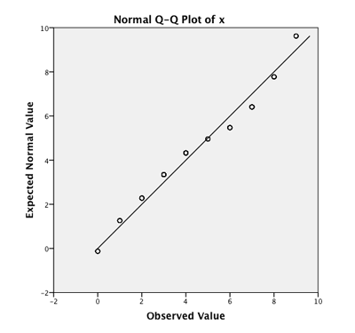

**R**

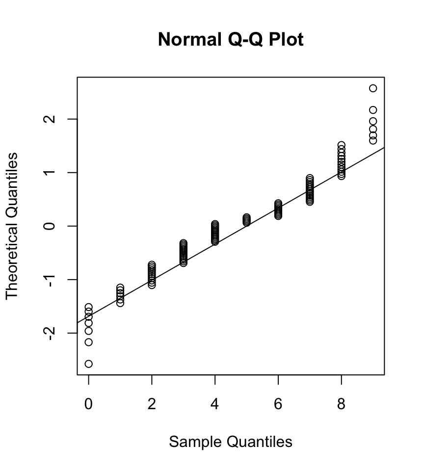

```r
qqnorm(x, datax=T)      # uses Blom's method by default
qqline(x, datax=T)
```

There are some obvious differences:

1. The most obvious one is that the R plot seems to contain more data points than the SPSS plot. Actually, this is not the case. Some data points are plotted on top of each in SPSS while they are spread out vertically in the R plot. The reason for this difference is that SPSS uses a different approach assigning probabilities to the values. We will expore the two approaches below.
2. The scaling of the y-axis differs. R uses quantiles from the standard normal distribution. SPSS by default rescales these values using the mean and standard deviation from the original data. This allows to directly compare the original and theoretical values. This is a simple linear transformation and will not be explained any further here.
3. The QQ-lines are not identical. R uses the 1st and 3rd quartile from both distributions to draw the line. This is different in SPSS where of a line is drawn for identical values on both axes. We will expore the differences below.

# QQ-plots from scratch

To get a better understanding of the difference we will build the R and SPSS-flavored QQ-plot from scratch.

## R type

In order to calculate theoretical quantiles corresponding to the observed values, we first need to find a way to assign a probability to each value of the original data. A lot of different approaches exist for this purpose (for an overview see e.g. [Castillo-Gutiérrez, Lozano-Aguilera, & Estudillo-Martínez, 2012b](http://davidpublishing.org/show.html?4874)). They usually build on the ranks of the observed data points to calculate corresponding p-values, i.e. the plotting positions for each point. The `qqnorm` function uses two formulae for this purpose, depending on the number of observations $n$ (Blom’s mfethod, see `?qqnorm`; Blom, 1958). With $r$ being the rank, for $n > 10$ it will use the formula $p = (r - 1/2) / n$, for $n \leq 10$ the formula $p = (r - 3/8) / (n + 1/4)$ to determine the probability value $p$ for each observation (see the help files for the functions `qqnorm` and `ppoint`). For simplicity reasons, we will only implement the $n > 10$ case here.

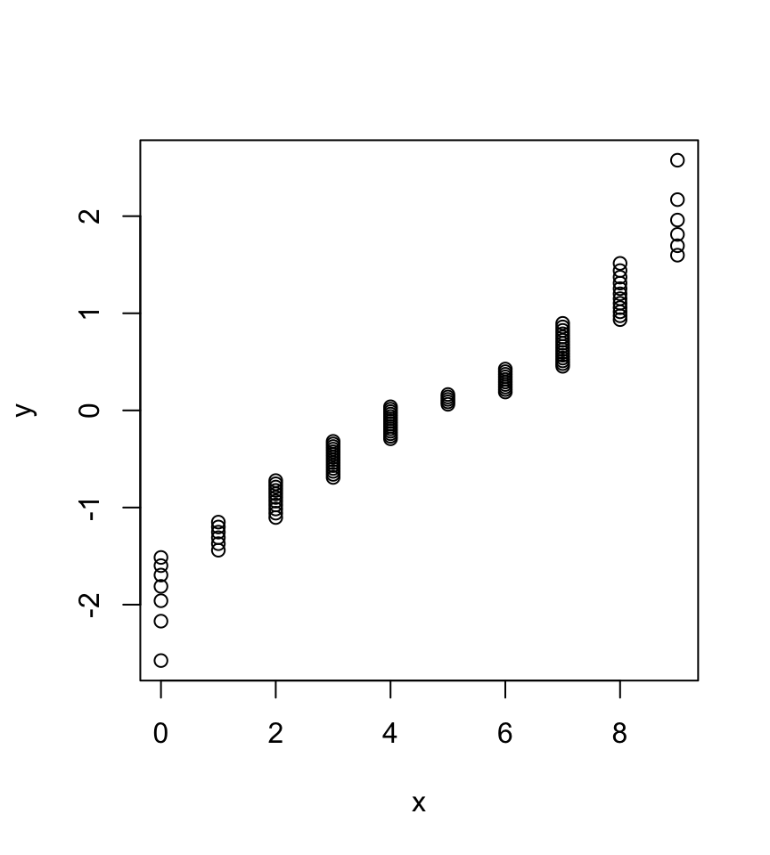

```r
n <- length(x)          # number of observations
r <- order(order(x))    # order of values, i.e. ranks without averaged ties
p <- (r - 1/2) / n      # assign to ranks using Blom's method
y <- qnorm(p)           # theoretical standard normal quantiles for p values
plot(x, y)              # plot empirical against theoretical values
```

Before we take at look at the code, note that our plot is identical to the plot generated by `qqnorm` above, except that the QQ-line is missing. The main point that makes the difference between R and SPSS is found in the command `order(order(x))`. The command calculates ranks for the observations using [ordinal ranking](http://en.wikipedia.org/wiki/Ranking). This means that all observations get different ranks and no average ranks are calculated for ties, i.e. for observations with equal values. Another approach would be to apply [fractional ranking](http://en.wikipedia.org/wiki/Ranking) and calculate average values for ties. This is what the function `rank` does. The following codes shows the difference between the two approaches to assign ranks.

```r
v <- c(1,1,2,3,3)
order(order(v))     # ordinal ranking used by R
```

```
## [1] 1 2 3 4 5
```

```r
rank(v)             # fractional ranking used by SPSS
```

```
## [1] 1.5 1.5 3.0 4.5 4.5
```

R uses *ordinal ranking* and SPSS uses *fractional ranking* by default to assign ranks to values. Thus, the positions do not overlap in R as each ordered observation is assigned a different rank and therefore a different p-value. We will pick up the second approach again later, when we reproduce the SPSS-flavored plot in R.[^1]

The second difference between the plots concerned the scaling of the y-axis and was already clarified above.

The last point to understand is how the QQ-line is drawn in R. Looking at the `probs` argument of `qqline` reveals that it uses the 1st and 3rd quartile of the original data and theoretical distribution to determine the reference points for the line. We will draw the line between the quartiles in red and overlay it with the line produced by `qqline` to see if our code is correct.

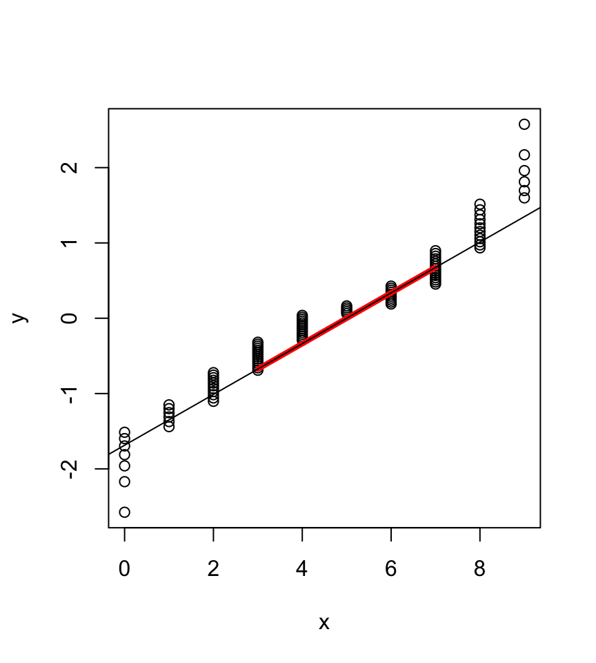

```r
plot(x, y)                      # plot empirical against theoretical values
ps <- c(.25, .75)               # reference probabilities
a <- quantile(x, ps)            # empirical quantiles
b <- qnorm(ps)                  # theoretical quantiles
lines(a, b, lwd=4, col="red")   # our QQ line in red
qqline(x, datax=T)              # R QQ line
```

The reason for different lines in R and SPSS is that several approaches to fitting a straight line exist (for an overview see e.g. [Castillo-Gutiérrez, Lozano-Aguilera, & Estudillo-Martínez, 2012a](http://davidpublishing.org/show.html?8305)). Each approach has different advantages. The method used by R is more robust when we expect values to diverge from normality in the tails, and we are primarily interested in the normality of the middle range of our data. In other words, the method of fitting an adequate QQ-line depends on the purpose of the plot. An explanation of the rationale of the R approach can e.g. be found [here](http://stats.stackexchange.com/questions/22258/what-is-the-use-of-the-line-produced-by-qqline-in-r).